# Visualizing spectral variation

Jose Eduardo Meireles

July 2026

A single reflectance curve is easy to read; a few hundred of them stacked on one plot are not. This vignette is about *seeing* variation: coloring spectra by a grouping, summarizing spread with quantile bands, exposing the strong band-to-band redundancy that makes spectra behave like a handful of underlying signals, and extracting the dominant axes of variation with PCA. It uses both the base-R plotting in `spectrolab` and the tidy/`ggplot2` bridge (`to_long()`, `as_tibble()`, `autoplot()`).

Throughout we use the built-in `spec_matrix_example`, a **simulated** dataset of 50 spectra whose sample *names* encode 10 “species” – a convenient stand-in for a categorical grouping.

```r
s = as_spectra(spec_matrix_example, name_idx = 1)
dim(s)                     # 50 samples x 2101 bands (400-2500 nm)
```

```
#> n_samples   n_bands
#>        50      2101
```

```r
length(unique(names(s)))   # 10 groups, carried in the sample names
```

```
#> [1] 10
```

The `_common.R` helper (sourced above) supplies the shared visual language used in every vignette: a colorblind-safe categorical palette (`spec_pal`), sequential/diverging ramps (`spec_seq()`, `spec_div()`), light region tints (`spec_region_tints`), a `ggplot2` theme (`theme_spectra()`), and two grouping helpers. `species_cols(x)` returns a per-sample color vector; `group_palette(x)` returns the same mapping plus the named palette and levels needed to build a legend. Both cap the grouping at 8 colors and fold the rest into `"Other"`.

## Coloring spectra by a grouping (base R)

The workhorse is `plot.spectra()`. Passing a per-sample color vector from `species_cols()` turns an undifferentiated tangle of lines into a group-structured one. We shade the canonical spectral regions underneath with `plot_regions()` and build a legend from the named palette in `group_palette()`.

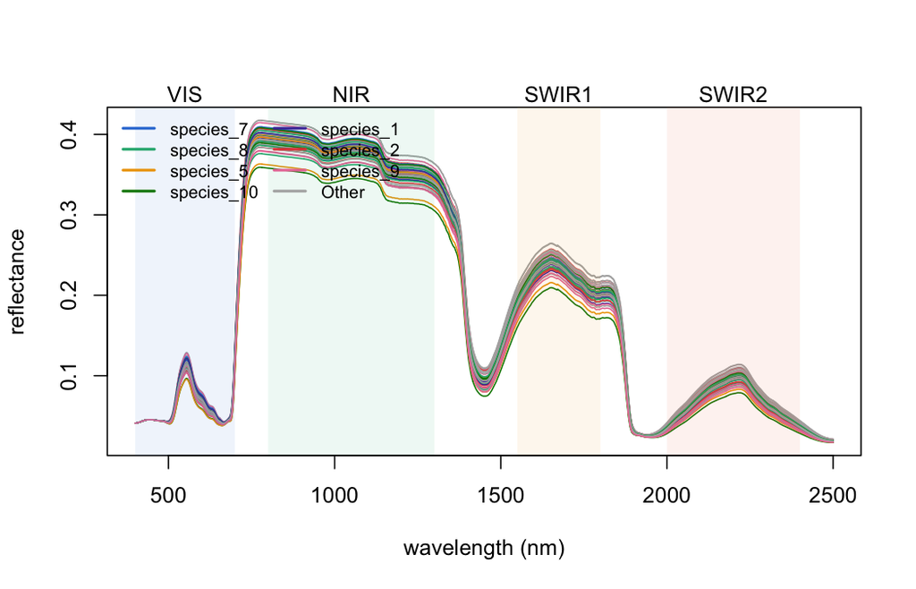

```r
gp = group_palette(s)

plot(s, col = species_cols(s), lwd = 1, ylab = "reflectance",
     xlab = "wavelength (nm)")
plot_regions(s, col = spec_region_tints)
legend("topleft", legend = names(gp$pal), col = gp$pal,
       lwd = 2, bty = "n", cex = 0.8, ncol = 2)
```

Even colored, 50 overlapping curves hide the *within-group* spread. A cleaner summary draws each group as a shaded quantile band instead of individual lines. We map every sample back to its (folded) group, then loop, calling `plot_quantile(add = TRUE)` on each subset with a translucent fill of that group’s color.

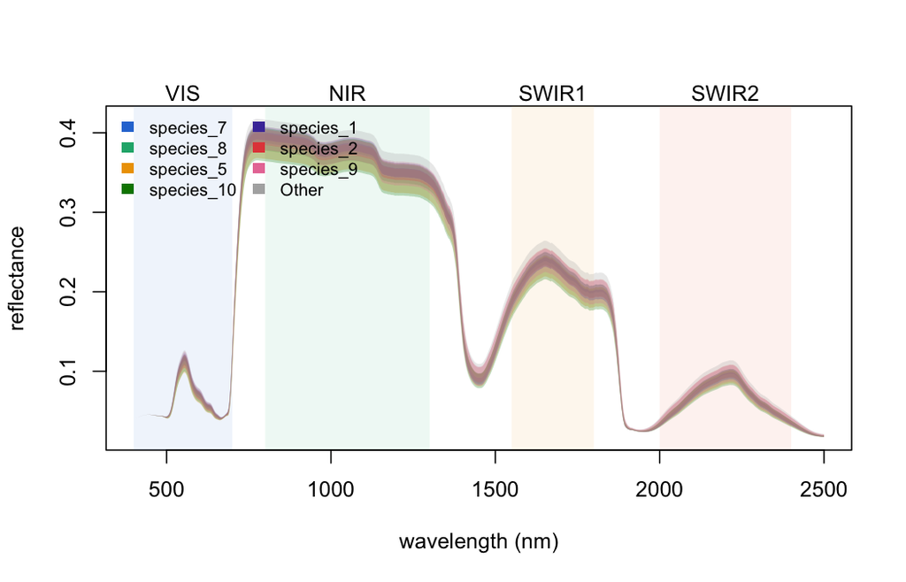

```r
grp_of = stats::setNames(names(gp$pal)[match(gp$cols, gp$pal)], names(s))

plot(s, type = "n", ylab = "reflectance", xlab = "wavelength (nm)")
plot_regions(s, col = spec_region_tints)

for(g in names(gp$pal)){
    idx = which(grp_of == g)
    if(length(idx) >= 2){
        plot_quantile(s[idx, ], total_prob = 0.9, add = TRUE, border = FALSE,
                      col = grDevices::adjustcolor(gp$pal[[g]], 0.25))
    }
}
legend("topleft", legend = names(gp$pal), fill = gp$pal, bty = "n",
       cex = 0.8, ncol = 2, border = NA)
```

## The tidy path: ggplot2

For grammar-of-graphics workflows, reshape to long format with `to_long()` (base R, no tidyverse required) and hand the result to `ggplot2`. Long format carries `sample_name`, `band`, and `value`; we add a stable per-spectrum `id` (sample names repeat across the 5 replicates per group, so grouping lines by name alone would connect unrelated samples) and the folded group so colors and legend match the base-R plots above.

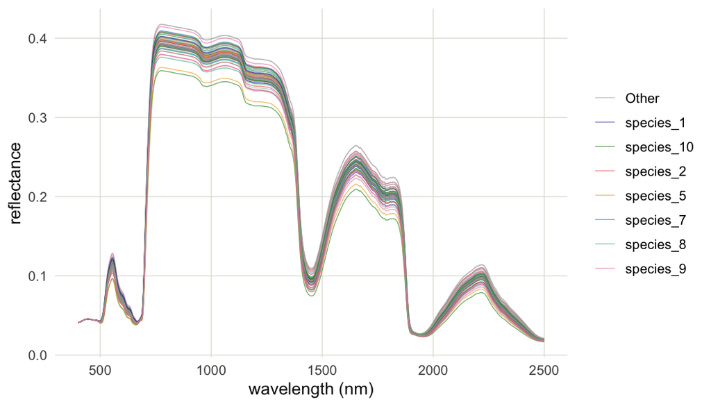

```r
long         = to_long(s)
long$id      = rep(seq_len(nrow(s)), times = ncol(s))
long$species = rep(grp_of, times = ncol(s))

ggplot2::ggplot(long, ggplot2::aes(band, value, group = id, colour = species)) +
    ggplot2::geom_line(alpha = 0.6, linewidth = 0.3) +
    ggplot2::scale_colour_manual(values = group_palette(s)$pal) +
    ggplot2::labs(x = "wavelength (nm)", y = "reflectance", colour = NULL) +
    theme_spectra()
```

Because the long data is a plain data.frame, the rest of the grammar composes normally. `facet_wrap()` breaks the overplotted bundle into small multiples – one panel per group, which reads far better than a single crowded axis.

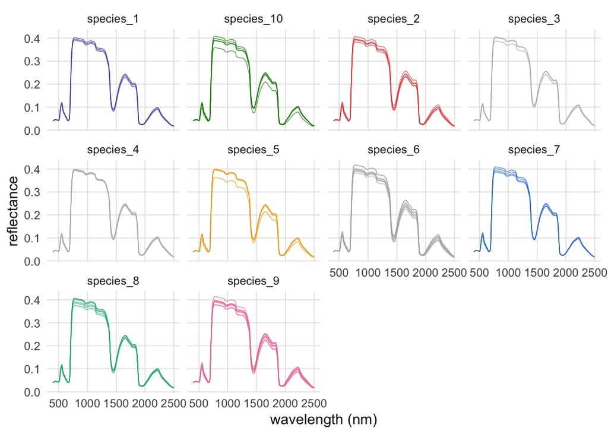

```r
ggplot2::ggplot(long, ggplot2::aes(band, value, group = id, colour = species)) +
    ggplot2::geom_line(alpha = 0.7, linewidth = 0.3, show.legend = FALSE) +
    ggplot2::scale_colour_manual(values = group_palette(s)$pal) +
    ggplot2::facet_wrap(~ sample_name) +
    ggplot2::labs(x = "wavelength (nm)", y = "reflectance") +
    theme_spectra()
```

The `ggplot2` equivalent of the shaded quantile band is `geom_ribbon()`. Compute per-band quantiles with `quantile()` – which returns one spectrum per probability – then plot the outer probabilities as a ribbon and the median as a line.

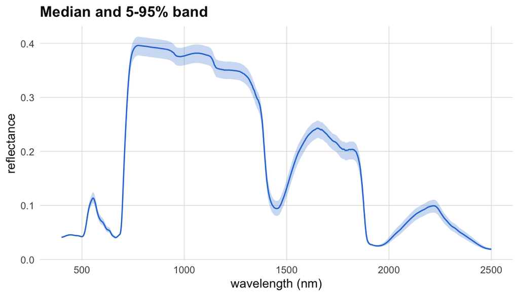

```r
qt  = quantile(s, probs = c(0.05, 0.5, 0.95))
qv  = value(qt)
fan = data.frame(band = bands(qt), lo = qv[1, ], mid = qv[2, ], hi = qv[3, ])

ggplot2::ggplot(fan, ggplot2::aes(band)) +
    ggplot2::geom_ribbon(ggplot2::aes(ymin = lo, ymax = hi),
                         fill = spec_pal[1], alpha = 0.25) +
    ggplot2::geom_line(ggplot2::aes(y = mid), colour = spec_pal[1], linewidth = 0.6) +
    ggplot2::labs(x = "wavelength (nm)", y = "reflectance",
                  title = "Median and 5-95% band") +
    theme_spectra()
```

For a one-liner default, `autoplot(s)` draws all spectra as a bare `ggplot` object you can extend. Note that `autoplot()` drops metadata, so it cannot color by a grouping on its own – when you need groups, go through `to_long()` as above and add the color aesthetic yourself.

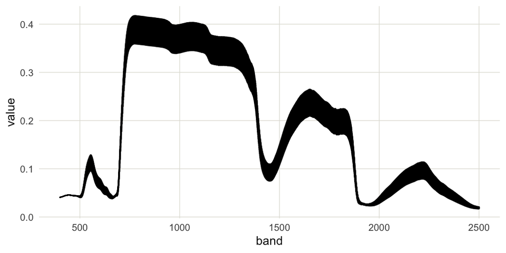

```r
ggplot2::autoplot(s) + theme_spectra()
```

## Spectral redundancy: band autocorrelation

Adjacent bands measure almost the same thing, which is why a 2101-band spectrum carries far fewer than 2101 independent numbers. The band-by-band correlation matrix makes this concrete. A full-resolution `cor()` would be a 2101x2101 matrix – needless compute and a multi-megabyte figure – so we first downsample to ~10 nm resolution with `resample()`.

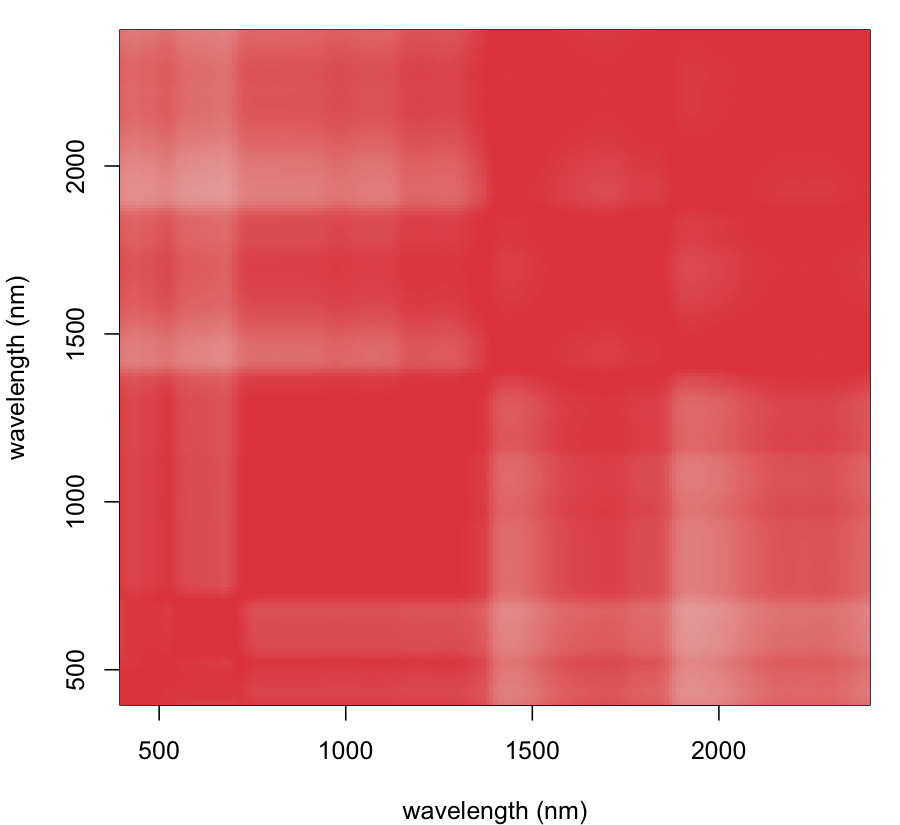

```r
sc = resample(s, seq(400, 2400, by = 10), fwhm = 10)   # ~200 bands
M  = cor(as.matrix(sc))
wl = bands(sc)

op = graphics::par(mar = c(4, 4, 1, 1))
image(x = wl, y = wl, z = M, zlim = c(-1, 1),
      col = spec_div(255), useRaster = TRUE,
      xlab = "wavelength (nm)", ylab = "wavelength (nm)")
```

```r
graphics::par(op)
```

## Dominant axes: PCA

Principal component analysis rotates the band axes into a new set of orthogonal axes ordered by the variance they explain. Because spectra are so redundant, the first two or three components typically capture the overwhelming majority of the variation. We run `prcomp()` on the sample-by-band matrix.

```r
pca = prcomp(as.matrix(s), center = TRUE)
imp = summary(pca)$importance
round(imp[, 1:5], 4)
```

```
#>                           PC1    PC2    PC3    PC4    PC5
#> Standard deviation     0.3743 0.1152 0.0321 0.0041 0.0018
#> Proportion of Variance 0.9072 0.0859 0.0067 0.0001 0.0000
#> Cumulative Proportion  0.9072 0.9932 0.9998 1.0000 1.0000
```

```r
ve  = round(imp[2, 1:2] * 100, 1)   # % variance explained by PC1, PC2
ve
```

```
#>  PC1  PC2
#> 90.7  8.6
```

A score scatter of PC1 versus PC2 places each sample in this reduced space; coloring by group shows how the axes relate to the categorical structure.

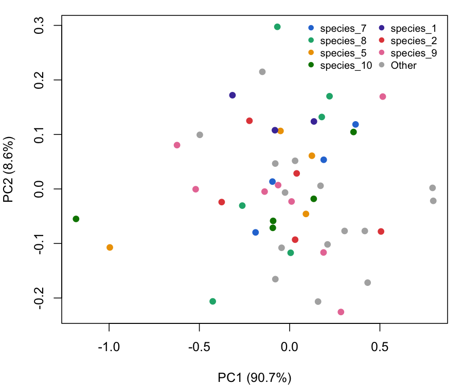

```r
lab = paste0(c("PC1", "PC2"), " (", ve, "%)")

op = graphics::par(mar = c(4, 4, 1, 1))
plot(pca$x[, 1], pca$x[, 2], col = species_cols(s), pch = 19,
     xlab = lab[1], ylab = lab[2])
legend("topright", legend = names(gp$pal), col = gp$pal, pch = 19,
       bty = "n", cex = 0.8, ncol = 2)
```

```r
graphics::par(op)
```

The scores tell you *where* samples sit; the loadings tell you *which wavelengths* build each axis. Plotting `pca$rotation` over wavelength – a “loadings-as-spectra” view – reveals the spectral fingerprint of each component. We set up an empty plotting frame, shade the regions, then overlay the first two loading vectors.

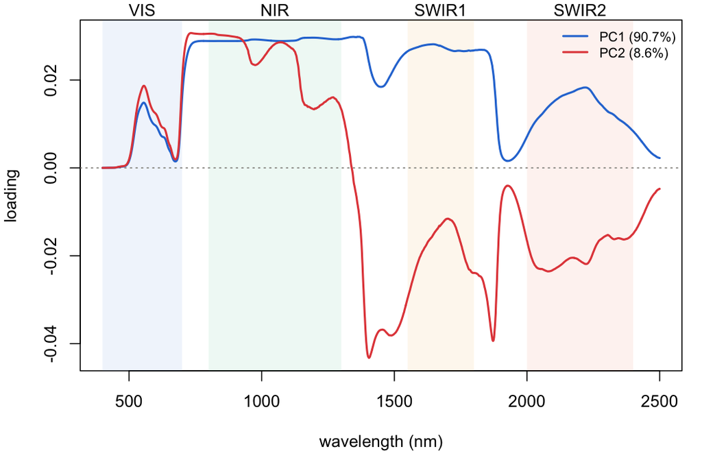

```r
rot = pca$rotation[, 1:2]
wl2 = bands(s)

op = graphics::par(mar = c(4, 4, 1, 1))
matplot(wl2, rot, type = "n", xlab = "wavelength (nm)", ylab = "loading")
plot_regions(s, col = spec_region_tints)
graphics::abline(h = 0, col = spec_muted, lty = 3)
graphics::matlines(wl2, rot, col = c(spec_pal[1], spec_pal[6]), lty = 1, lwd = 2)
legend("topright", legend = lab, col = c(spec_pal[1], spec_pal[6]),
       lwd = 2, bty = "n", cex = 0.8)
```

```r
graphics::par(op)
```

Peaks and troughs in a loading mark the bands that drive that component; a loading flat near zero means those wavelengths contribute nothing to that axis. Reading the scores and loadings together – which samples separate along an axis, and which wavelengths define it – is the core of interpreting spectral variation.

## Data note

`spec_matrix_example` is **simulated**. Real reflectance would show cleaner, more textbook structure – sharper water-absorption features, a crisper red edge, and correlation blocks that align even more tightly with the pigment, water, and dry-matter absorptions that organize plant spectra. The workflow, however, is identical on measured data.